# DATA 605 FUNDAMENTALS OF COMPUTATIONAL MATHEMATICS

Discussion 12: Multiple Linear Regression

Kyle Gilde

11/15/2017

```
##           installed_and_loaded.packages.
## prettydoc                           TRUE
## dplyr                               TRUE
## gvlma                               TRUE
## MASS                                TRUE
## lmtest                              TRUE
## car                                 TRUE
```

Using R, build a multiple regression model for data that interests you.

Include in this model at least one quadratic term, one dichotomous term, and one dichotomous vs. quantitative interaction term.

- Interpret all coefficients.
- Conduct residual analysis.
- Was the linear model appropriate? Why or why not?

# Multiple LR with Wine Data Set

Last week, I created a univarate LM using the wine’s color intensity to predict the alcohol content, but it only accounted for 30% of the variation. Let’s see if we can find a better multiple linear model for a wine’s alcohol content.

## Background Info on Data

“These data are the results of a chemical analysis of wines grown in the same region in Italy but derived from three different cultivars. The analysis determined the quantities of 13 constituents found in each of the three types of wines.” [UCI Machine Learning Repository](http://archive.ics.uci.edu/ml/datasets/Wine)

```r
url <- "http://archive.ics.uci.edu/ml/machine-learning-databases/wine/wine.data"

wine_df <- read.csv(url, header = F)

names(wine_df) <- c("cultivars", "Alcohol", "Malic_acid", "Ash", "Alcalinity_of_ash",
    "Magnesium", "Total_phenols", "Flavanoids", "Nonflavanoid_phenols", "Proanthocyanins",
    "Color_intensity", "Hue", "OD280_OD315_of_dilutedwines", "Proline")

glimpse(wine_df)
```

```
## Observations: 178
## Variables: 14
## $ cultivars                   <int> 1, 1, 1, 1, 1, 1, 1, 1, 1, 1, 1, 1...
## $ Alcohol                     <dbl> 14.23, 13.20, 13.16, 14.37, 13.24,...
## $ Malic_acid                  <dbl> 1.71, 1.78, 2.36, 1.95, 2.59, 1.76...
## $ Ash                         <dbl> 2.43, 2.14, 2.67, 2.50, 2.87, 2.45...
## $ Alcalinity_of_ash           <dbl> 15.6, 11.2, 18.6, 16.8, 21.0, 15.2...
## $ Magnesium                   <int> 127, 100, 101, 113, 118, 112, 96, ...
## $ Total_phenols               <dbl> 2.80, 2.65, 2.80, 3.85, 2.80, 3.27...
## $ Flavanoids                  <dbl> 3.06, 2.76, 3.24, 3.49, 2.69, 3.39...
## $ Nonflavanoid_phenols        <dbl> 0.28, 0.26, 0.30, 0.24, 0.39, 0.34...
## $ Proanthocyanins             <dbl> 2.29, 1.28, 2.81, 2.18, 1.82, 1.97...
## $ Color_intensity             <dbl> 5.64, 4.38, 5.68, 7.80, 4.32, 6.75...
## $ Hue                         <dbl> 1.04, 1.05, 1.03, 0.86, 1.04, 1.05...
## $ OD280_OD315_of_dilutedwines <dbl> 3.92, 3.40, 3.17, 3.45, 2.93, 2.85...
## $ Proline                     <int> 1065, 1050, 1185, 1480, 735, 1450,...
```

Before proceeding with the model, let’s get R to treat the cultivars like the categorical variable that it is by converting it to a factor.

```r
wine_df$cultivars <- as.factor(wine_df$cultivars)
```

## Pairs

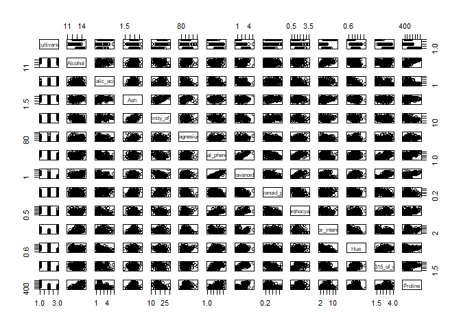

```r
pairs(wine_df)
```

## Model Summary

```r
# wine_df$Color_intensity <- log(wine_df$Color_intensity)
wine_model <- lm(Alcohol ~ cultivars + Malic_acid + Ash + Alcalinity_of_ash +
    Magnesium + Total_phenols + Flavanoids + Nonflavanoid_phenols + Proanthocyanins +
    Color_intensity + Hue + OD280_OD315_of_dilutedwines + Proline, wine_df)

summary(wine_model)
```

```
##
## Call:
## lm(formula = Alcohol ~ cultivars + Malic_acid + Ash + Alcalinity_of_ash +
##     Magnesium + Total_phenols + Flavanoids + Nonflavanoid_phenols +
##     Proanthocyanins + Color_intensity + Hue + OD280_OD315_of_dilutedwines +
##     Proline, data = wine_df)
##
## Residuals:
##      Min       1Q   Median       3Q      Max
## -1.28644 -0.32082 -0.01968  0.32130  1.55798
##
## Coefficients:
##                               Estimate Std. Error t value Pr(>|t|)
## (Intercept)                 12.8897743  0.6520965  19.767  < 2e-16 ***
## cultivars2                  -1.1190123  0.1977998  -5.657 6.76e-08 ***
## cultivars3                  -0.7246470  0.2977755  -2.434   0.0160 *
## Malic_acid                   0.0745271  0.0437377   1.704   0.0903 .
## Ash                         -0.2857993  0.2129813  -1.342   0.1815
## Alcalinity_of_ash            0.0043847  0.0180854   0.242   0.8087
## Magnesium                   -0.0001002  0.0030792  -0.033   0.9741
## Total_phenols                0.0987638  0.1245065   0.793   0.4288
## Flavanoids                  -0.0504991  0.1152621  -0.438   0.6619
## Nonflavanoid_phenols        -0.0372904  0.4047649  -0.092   0.9267
## Proanthocyanins             -0.0671147  0.0912196  -0.736   0.4629
## Color_intensity              0.1243005  0.0300102   4.142 5.52e-05 ***
## Hue                          0.3521632  0.2630523   1.339   0.1825
## OD280_OD315_of_dilutedwines  0.0307750  0.1090821   0.282   0.7782
## Proline                      0.0001729  0.0002380   0.726   0.4687
## ---
## Signif. codes:  0 '***' 0.001 '**' 0.01 '*' 0.05 '.' 0.1 ' ' 1
##
## Residual standard error: 0.4912 on 163 degrees of freedom
## Multiple R-squared:  0.6628, Adjusted R-squared:  0.6339
## F-statistic: 22.89 on 14 and 163 DF,  p-value: < 2.2e-16
```